# A summary of the tweets generated at Botany 2020 (#Botany2020)

E.J. Rollinson

## About this document

This document was produced by [Emily J. Rollinson](http://rollinsonecology.com) ([@ejrollinson](https://twitter.com/ejrollinson) on Twitter).

The code generating this document was originally developed by [Francois Michonneau](https://github.com/fmichonneau) ([@fmic_](https://twitter.com/fmic_) on Twitter) for the 2015 Evolution meeting and can be found [here](https://github.com/fmichonneau/evol2015-tweets).

I originally adapted this code for the 2015 Ecological Society of America meeting (#ESA100) in Baltimore, MD, and have since reproduced it for a series of ESA and Botany meetings. I also modified it in 2020 to use the rtweet package instead of twitteR to aggregate tweets, updated the code used to generate the wordcloud, and modified the formatting of the plots.

Tweets using the hashtag #Botany2020 were aggregated from Twitter using the R package [rtweet](https://cran.r-project.org/web/packages/rtweet/index.html) and the Twitter API. The summary statistics are static as of 8:00 AM EDT Aug 01 2020 (additional tweets, retweets, and likes after that point are not included).

This document was generated using RMarkdown, and the source is [available on GitHub](https://github.com/erollinson/erollinson.github.io).

This document (and associated code) is released under a CC0 licence.

## Basic summary

Of the 12338 tweets tagged #Botany2020 between 2020-07-27 and 2020-07-31:

| Description | n |
| --- | --- |
| Total of original tweets (no retweets): | 3489 |
| Number of users who tweeted (including retweeting): | 1980 |
| Number of users who tweeted (no retweets): | 443 |

## The 5 most liked tweets

> My Forbes debut. 😊 #scicomm #blackafinstem #scientist #blackinnature #FossilFriday #phdchat #phdlife #Botany2020 #blackbotanicallegacy #paleoart

> Fossil Plants Could Help This South African Solve A 200-Year Puzzle via @forbes https://t.co/qB9z39Lmnq — UdeMischa | [2020-07-27](https://twitter.com/UdeMischa/status/1287647654009344001) | 134 retweets, 470 likes

> Because every day is #pride day and because #iamabotanist, here’s a rainbow made exclusively by flowers of all families of #Commelinales #Botany2020 https://t.co/oza6YW683h

> — MarcoPe52646856 | [2020-07-30](https://twitter.com/MarcoPe52646856/status/1288985894322606080) | 91 retweets, 431 likes

> As #Botany2020 ends, I’m also officially retired from my position as student rep of @Botanical_. It’s been a pleasure to serve the #Iamabotanist community for 2 years & I got so much support from many people. Here’s my Thank You dance performed by me in a forest with some fronds. https://t.co/QT3uVeaDQq

> — 0_minyaaa | [2020-07-31](https://twitter.com/0_minyaaa/status/1289299376796504064) | 16 retweets, 244 likes

> Thrilled to have won the Cooley award at #Botany2020. Women in STEM and people doing #cienciacriolla have all the potential but we need opportunities. Thanks to the @AmSocPlantTaxon for supporting my research from the begging with the research award

> — botAna_Bedoya | [2020-07-30](https://twitter.com/botAna_Bedoya/status/1288955980504473600) | 30 retweets, 238 likes

> Cindi Jones shows what botanists see and I feel seen. #Botany2020 #iamabotanist https://t.co/mUWnE8axKh

> — MartineBotany | [2020-07-31](https://twitter.com/MartineBotany/status/1289279368896761856) | 54 retweets, 222 likes

## The 5 most retweeted tweets

> My Forbes debut. 😊 #scicomm #blackafinstem #scientist #blackinnature #FossilFriday #phdchat #phdlife #Botany2020 #blackbotanicallegacy #paleoart

> Fossil Plants Could Help This South African Solve A 200-Year Puzzle via @forbes https://t.co/qB9z39Lmnq — UdeMischa | [2020-07-27](https://twitter.com/UdeMischa/status/1287647654009344001) | 134 retweets, 470 likes

> Because every day is #pride day and because #iamabotanist, here’s a rainbow made exclusively by flowers of all families of #Commelinales #Botany2020 https://t.co/oza6YW683h

> — MarcoPe52646856 | [2020-07-30](https://twitter.com/MarcoPe52646856/status/1288985894322606080) | 91 retweets, 431 likes

> Missing #Botany2020 this year, but if you are intersted in pursuing a Master’s degree working on plant systematics, phylogenetics, and biogeography, reach out to me. I’m looking for students for fall 2021, come and study in the redwoods @HSUBiology https://t.co/ca03yjvyW2

> — Oscarmvargash | [2020-07-28](https://twitter.com/Oscarmvargash/status/1288156149645099009) | 61 retweets, 126 likes

> #Botany2020 I am recruiting a PhD student to study how rapid evolution impacts species coexistence using #duckweed. Come conduct experimental evolution in the field and combine it with coexistence theory. Details: https://t.co/BuflQniatq https://t.co/4l937MeKJc

> — Exp_EvoEco | [2020-07-28](https://twitter.com/Exp_EvoEco/status/1288211499568246785) | 58 retweets, 104 likes

> Cindi Jones shows what botanists see and I feel seen. #Botany2020 #iamabotanist https://t.co/mUWnE8axKh

> — MartineBotany | [2020-07-31](https://twitter.com/MartineBotany/status/1289279368896761856) | 54 retweets, 222 likes

## Top tweeters

All generated tweets (including retweets)

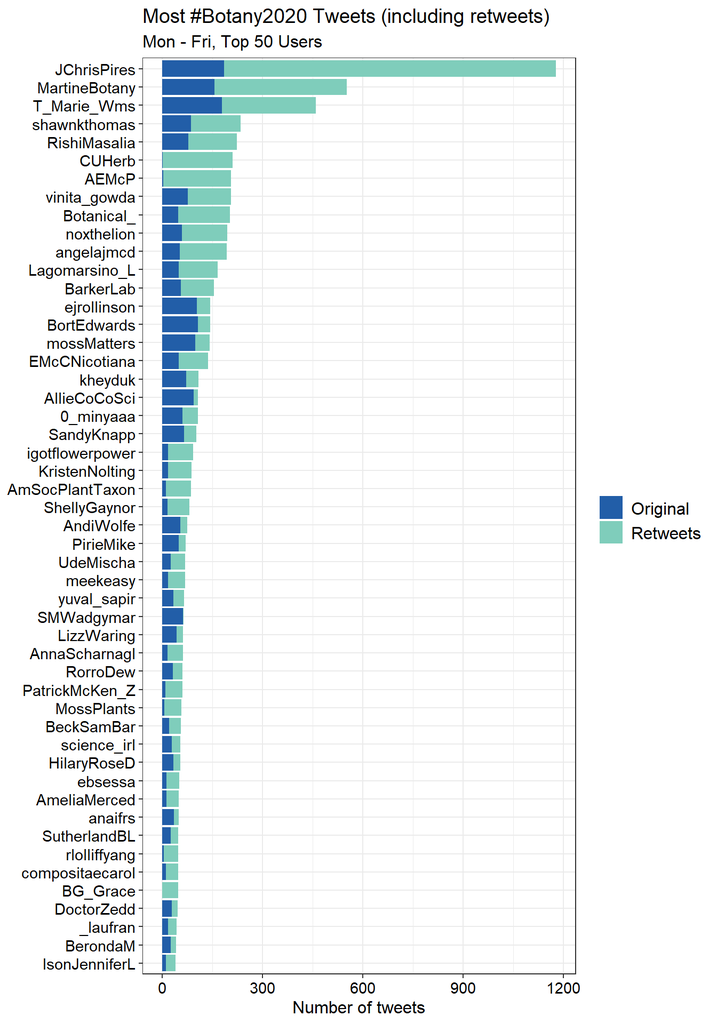

Only for original tweets (retweets excluded)

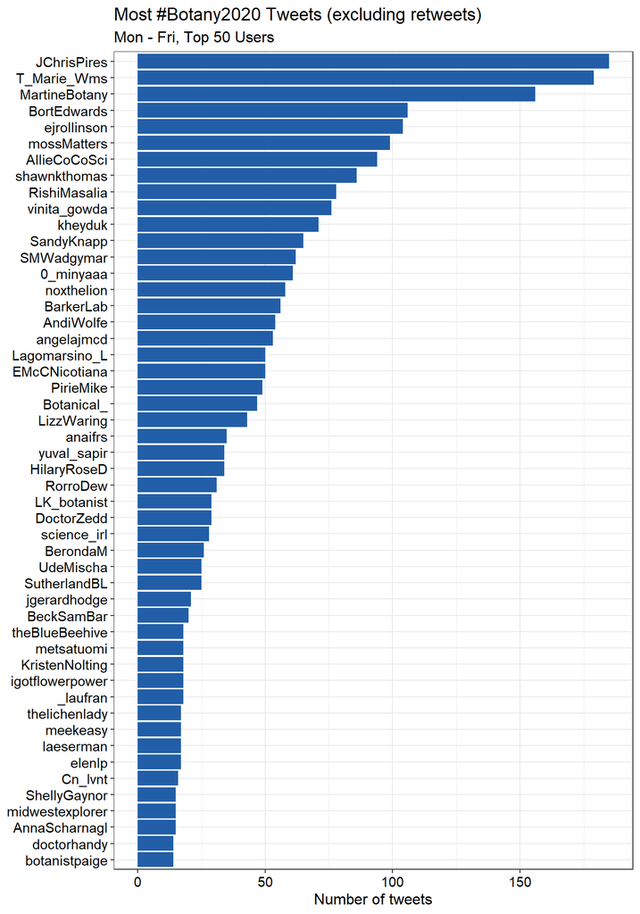

## Most favorited/retweeted users

### Number of favorites received by users

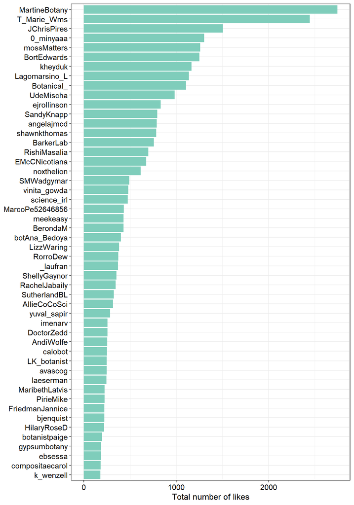

### Number of retweets received by users

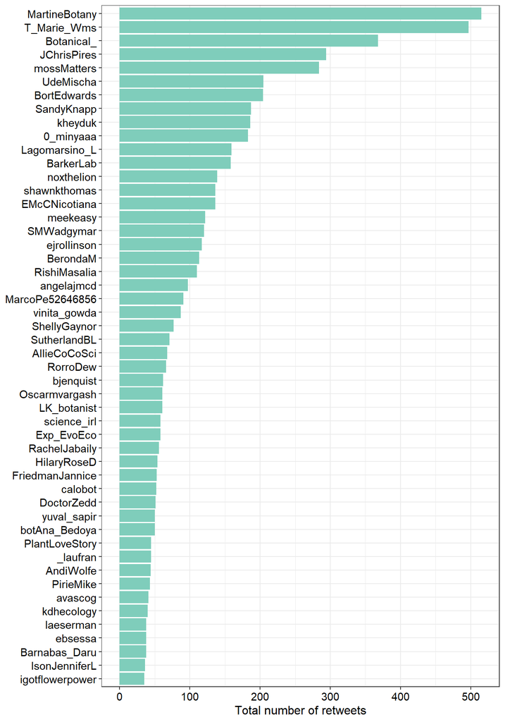

### Mean numbers of likes received

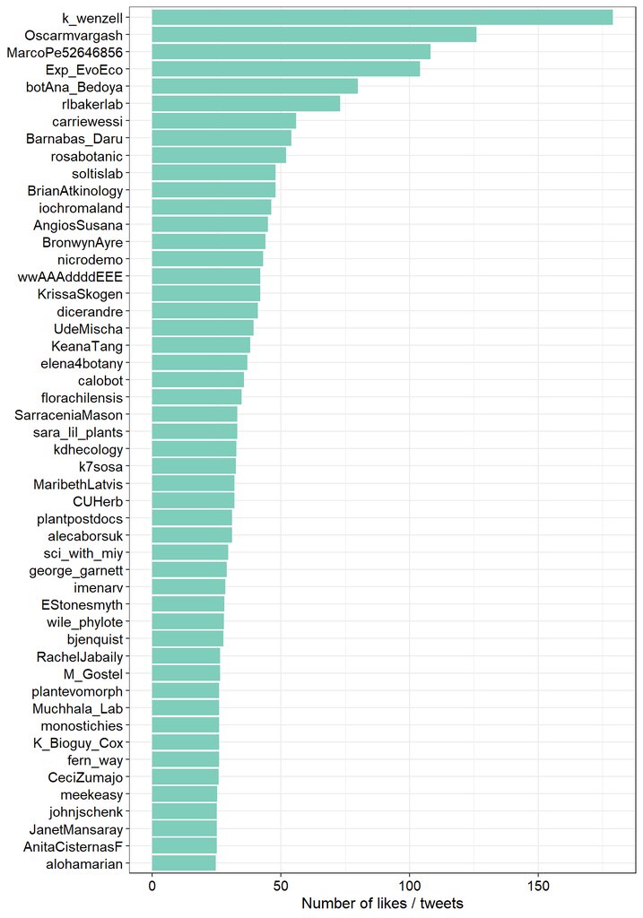

### Mean numbers of retweets received

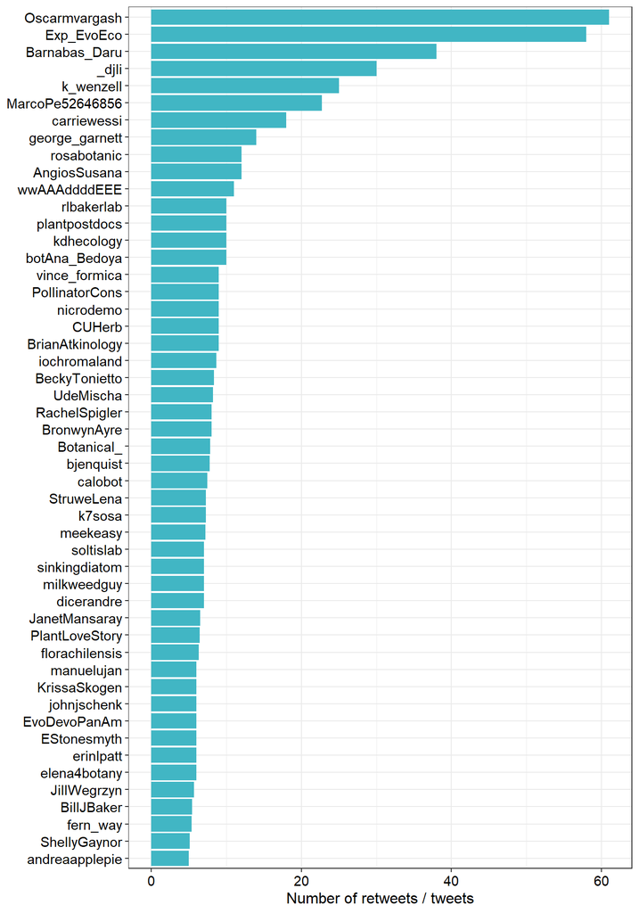

## Word cloud

The top 100 words among the original tweets, excluding retweets, hashtags, mentions, URLs, and common English words (“the’,”&", etc.).

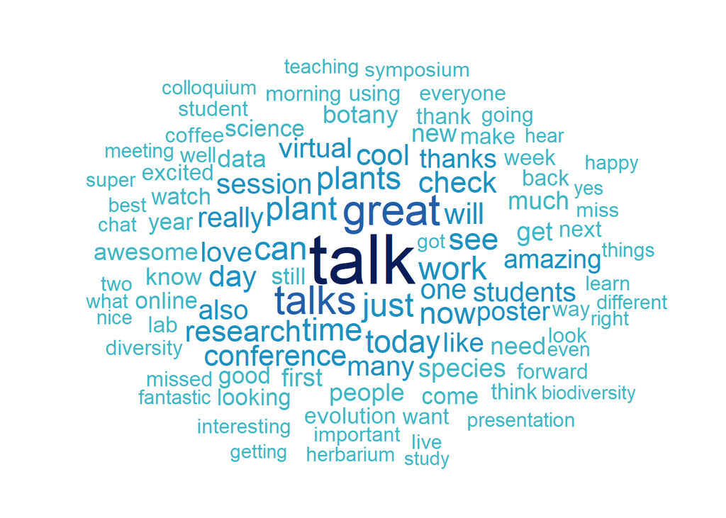

To the extent possible under law, [Emily J. Rollinson](https://github.com/erollinson/erollinson.github.io) has waived all copyright and related or neighboring rights to Summary of tweets at Botany 2020. This work is published from: United States.